# Introduction to Data Science Activity A3b: Multivariate Visualization I

# 1 Background on Visualizing Relationships

In making visualizations - and subsequently, statistical models - we are typically interested in the relationship between:

- **a response variable**: the variable whose variability we would like to explain
- **predictors**: variables that might explain some of the variability in the response

Our goal is to construct visualizations that allow us to examine/identify the following features of the relationships among these variables:

- relationship *trends*
- relationship *strength* (degree of variability from the trend)
- *outliers* in the relationship

Before constructing visualizations of the relationship among any set of these variables, we need to understand what features these should have. As with univariate plots, the appropriate visualization also depends upon whether the variables are quantitative or categorical. Recall some **basic rules in constructing graphics:**

- Each **quantitative variable** requires a new axis. (We’ll discuss later what to do when we run out of axes!)
- Each **categorical variable** requires a new way to “group” the graphic (eg: using colors, shapes, separate facets, etc to capture the grouping)
- For visualizations in which **overlap** in glyphs or plots obscures the patterns, try faceting or transparency.

# 2 Data Overview: Energy Consumption Per Capita

Today, we’ll use data from [Our World in Data](https://ourworldindata.org/energy-mix) on energy consumption per capita over time in different countries. Our World in Data pulls these data from Energy Institute - Statistical Review of World Energy (2023). The data are in kWh per capita for fossil fuels and in kWh equivalent per capita for the nuclear and renewables categories. One of the authors of this analysis, Hannah Ritchie, gave a [truly inspiring talk](https://www.youtube.com/watch?si=DZZXGQH_9Qugc5sT&v=Kl3VVrggKz4&feature=youtu.be) about using data science to characterize and take action towards sustainability. This is a fantastic use of simple visualizations to tell clear, not at all obvious stories.

We’ll use a subset of the data from the years 1991, 2001, 2011, and 2021. The following three data tables contain the same information in different forms (in a few weeks, we’ll learn easy ways to go back and forth between these different forms starting from any one of them):

```r
energy_per_capita1<-read_csv("http://faculty.olin.edu/dshuman/DS/energy_per_capita1.csv",col_type=list(year = col_factor(),less_than_eighty_percent_fossil_fuels=col_logical()))
energy_per_capita2<-read_csv("http://faculty.olin.edu/dshuman/DS/energy_per_capita2.csv",col_type=list(year = col_factor()))
energy_per_capita3<-read_csv("http://faculty.olin.edu/dshuman/DS/energy_per_capita3.csv",col_type=list(year = col_factor()))
```

Here are the first eight rows of each table:

Table 2.1: A subset of the energy_per_capita1 data table.

| country | code | year | fossil_fuels | nuclear | renewables | less_than_eighty_percent_fossil_fuels |
| --- | --- | --- | --- | --- | --- | --- |
| Algeria | DZA | 1991 | 11908.999 | 0.0000 | 33.15225 | FALSE |
| Algeria | DZA | 2001 | 9955.143 | 0.0000 | 6.49683 | FALSE |
| Algeria | DZA | 2011 | 12680.638 | 0.0000 | 29.90281 | FALSE |
| Algeria | DZA | 2021 | 15873.962 | 0.0000 | 40.50172 | FALSE |
| Argentina | ARG | 1991 | 13653.088 | 664.7714 | 1430.06570 | FALSE |
| Argentina | ARG | 2001 | 14777.170 | 530.9416 | 2902.00850 | FALSE |
| Argentina | ARG | 2011 | 19097.164 | 408.0380 | 2389.66460 | FALSE |
| Argentina | ARG | 2021 | 18364.658 | 563.9960 | 2399.53220 | FALSE |

Table 2.2: A subset of the energy_per_capita2 data table.

| country | code | fossil_fuels_1991 | fossil_fuels_2001 | fossil_fuels_2011 | fossil_fuels_2021 | nuclear_1991 | nuclear_2001 | nuclear_2011 | nuclear_2021 | renewables_1991 | renewables_2001 | renewables_2011 | renewables_2021 |
| --- | --- | --- | --- | --- | --- | --- | --- | --- | --- | --- | --- | --- | --- |
| Algeria | DZA | 11908.9990 | 9955.143 | 12680.638 | 15873.962 | 0.0000 | 0.0000 | 0.000 | 0.000 | 33.15225 | 6.496830 | 29.90281 | 40.50172 |
| Argentina | ARG | 13653.0880 | 14777.170 | 19097.164 | 18364.658 | 664.7714 | 530.9416 | 408.038 | 563.996 | 1430.06570 | 2902.008500 | 2389.66460 | 2399.53220 |
| Australia | AUS | 56551.4730 | 65693.060 | 65748.540 | 53517.137 | 0.0000 | 0.0000 | 0.000 | 0.000 | 2813.95870 | 2645.212200 | 3965.65140 | 7922.77050 |
| Austria | AUT | 32820.0550 | 34883.000 | 32799.523 | 28916.210 | 0.0000 | 0.0000 | 0.000 | 0.000 | 12503.52000 | 15538.107000 | 14400.96100 | 16324.84000 |
| Azerbaijan | AZE | 32520.6110 | 14900.381 | 14875.002 | 18583.152 | 0.0000 | 0.0000 | 0.000 | 0.000 | 690.10980 | 461.488560 | 788.71600 | 391.18164 |
| Bangladesh | BGD | 629.5759 | 1159.468 | 1789.195 | 2811.395 | 0.0000 | 0.0000 | 0.000 | 0.000 | 22.68302 | 22.155485 | 17.19926 | 19.76727 |
| Belarus | BLR | 44451.1300 | 24298.285 | 30903.950 | 30101.766 | 0.0000 | 0.0000 | 0.000 | 1515.353 | 5.08967 | 8.639523 | 77.13713 | 293.70490 |
| Belgium | BEL | 52027.8400 | 58480.180 | 50823.250 | 46640.120 | 12177.6150 | 12674.2470 | 11654.596 | 10882.972 | 165.74184 | 321.071750 | 2656.23300 | 6068.99460 |

Table 2.3: A subset of the energy_per_capita3 data table.

| country | code | year | energy_source | consumption_per_capita |
| --- | --- | --- | --- | --- |
| Algeria | DZA | 1991 | fossil_fuels | 11908.99900 |
| Algeria | DZA | 1991 | nuclear | 0.00000 |
| Algeria | DZA | 1991 | renewables | 33.15225 |
| Algeria | DZA | 2001 | fossil_fuels | 9955.14300 |
| Algeria | DZA | 2001 | nuclear | 0.00000 |
| Algeria | DZA | 2001 | renewables | 6.49683 |
| Algeria | DZA | 2011 | fossil_fuels | 12680.63800 |
| Algeria | DZA | 2011 | nuclear | 0.00000 |

**Exercise 2.1 (Explore the data)**

1. What are the units of observation for each; i.e., what does one row correspond to in each of the three tables?
2. What are the dimensions of each of the three tables?
3. How many countries are included in the data set?
4. Are there data for all four of the selected years for each of the included countries?

*Solution*.

1. - Table 2.1: A country and a year
   - Table 2.2: A country
   - Table 2.3: A country, a year, and an energy type
2. - Table 2.1: 284 x 7
   - Table 2.2: 73 x 14
   - Table 2.3: 852 x 5
3. 73
4. No, we would expect 73*4=292 rows in table 2.1, but there are only 284

# 3 Visualizing Quantitiative vs Quantitative Relationships

Let’s start by exploring the relationship between per capita fossil fuel energy consumption in 2001 (`fossil_fuels_2001`) and per capita fossil fuel energy consumption in 2021 (`fossil_fuels_2021`), both quantitative variables.

**Exercise 3.1 (Scatterplots and glyphs)** Both `fossil_fuels_2001` and `fossil_fuels_2021` are quantitative, thus require their own axes. Traditionally, the response variable is placed on the y-axis. Once the axes are set up, each case is represented by a “glyph” at the coordinates defined by these axes.

1. Which of the three tables do we want to use to make this plot? To answer this question, we want to think of the “one row per glyph” guiding rule of glyph-ready data.
2. Make a scatterplot of `fossil_fuels_2001` vs `fossil_fuels_2021` with point glyphs:

   ```r
   # for all of these, you'll need to change the X in energy_per_capitaX to 1, 2, or 3
   #just a graphics frame
   ggplot(energy_per_capita2, aes(y=fossil_fuels_2021, x=fossil_fuels_2001))  # it doesn't matter whether you specify the y or x aesthetic first

   #add a layer with "point" glyphs
   ggplot(energy_per_capita2, aes(y=fossil_fuels_2021, x=fossil_fuels_2001)) +
       geom_point()

   #add a layer with a diagonal line along y=x
   ggplot(energy_per_capita2, aes(y=fossil_fuels_2021, x=fossil_fuels_2001)) +
       geom_point() +
       geom_abline(linewidth=.3,linetype=3)
   ```

3. Summarize the relationship between fossil fuel energy consumption in 2001 and fossil fuel energy consumption in 2021. Be sure to comment on:  
   - the strength of the relationship (weak/moderate/strong)  
   - the direction of the relationship (positive/negative)  
   - outliers: what countries deviate from the trend?
4. Which points on the plot correspond to countries decreasing their per capita fossil fuel use over the 20-year period? Which correspond to countries increasing their per capita fossil fuel use over the 20-year period?
5. It would be nice to know which countries these points correspond to! We can do that by replacing the points (`geom_point()`) with text labels (`geom_text()`):

   ```r
   # Because we want the label to be different for each point, the `label=code` has to go inside of an `aes()`
   ggplot(energy_per_capita2, aes(y=fossil_fuels_2021, x=fossil_fuels_2001)) +
       geom_text(aes(label=code)) +
       geom_abline(linewidth=.3,linetype=3)
   ```

*Solution*.

# 4 Visualizing Quantitative vs. Categorical Relationships

Next, we are going to focus just on 2021 and try to understand the distributions of energy consumption per capita (a quantitative variable) by energy source (a categorical variable). First, we need to create a new table with just the data from 2021:

```r
energy_per_capita_2021<-read_csv("http://faculty.olin.edu/dshuman/DS/energy_per_capita_2021.csv",col_type=list(year = col_factor()))
```

Next, we’ll work through several plotting options.

1. Construct a density plot for each group.

   ```r
   ggplot(energy_per_capita_2021, aes(x=consumption_per_capita, fill=energy_source)) +
       geom_density()
   ```

2. Notice that `ggplot` randomly assigns colors to group based on alphabetical order. We can change this to specific colors as follows:

   ```r
   ggplot(energy_per_capita_2021, aes(x=consumption_per_capita, fill=energy_source)) +
       geom_density() +
       scale_fill_manual(values=c("red","yellow","green"))
   ```

3. The overlap between the groups makes it difficult to explore the features of each. One option is to add *transparency* to the density plots:

   ```r
   ggplot(energy_per_capita_2021, aes(x=consumption_per_capita, fill=energy_source)) +
     geom_density(alpha=.5) +
     scale_fill_manual(values=c("red","yellow","green"))
   ```

4. Yet another option is to separate the density plots into separate “facets” defined by group:

   ```r
   ggplot(energy_per_capita_2021, aes(x=consumption_per_capita, fill=energy_source)) +
     geom_density(alpha=.5) +
     scale_fill_manual(values=c("red","yellow","green"))+
     facet_wrap(~energy_source)
   ```

**Exercise 4.2 (Side-by-Side Histograms)** Let’s try a similar strategy using histograms to illustrate the relationship between `consumption_per_capita` and `energy_source`.

1. Start with the default histogram:

   ```r
   ggplot(energy_per_capita_2021, aes(x=consumption_per_capita, fill=energy_source)) +
     geom_histogram(color="white")
   ```

2. That’s not very helpful! Separate the histograms into separate facets for each `energy_source` group.

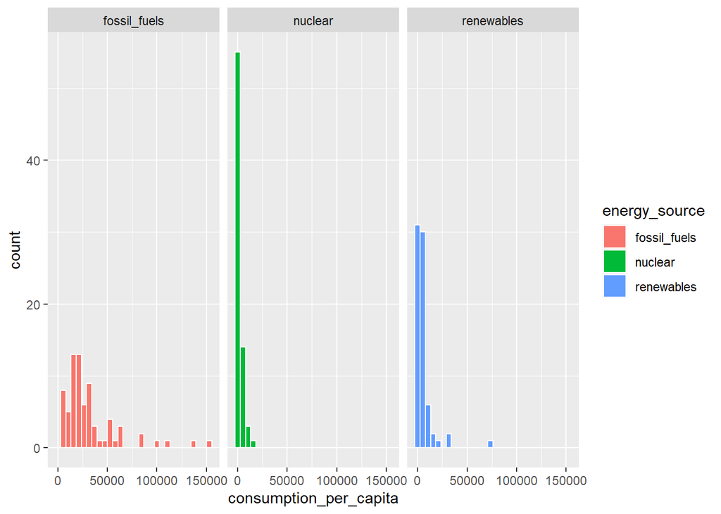

```r
ggplot(energy_per_capita_2021, aes(x=consumption_per_capita, fill=energy_source)) +
  geom_histogram(color="white") +
  facet_wrap(~energy_source)
```

**More Options**

Density plots and histograms aren’t the only type of viz we might use! We can construct side-by-side *boxplots*, which are constructed from five numbers - the minimum, 25th percentile, median, 75th percentile, and maximum value of a quantitative variable:

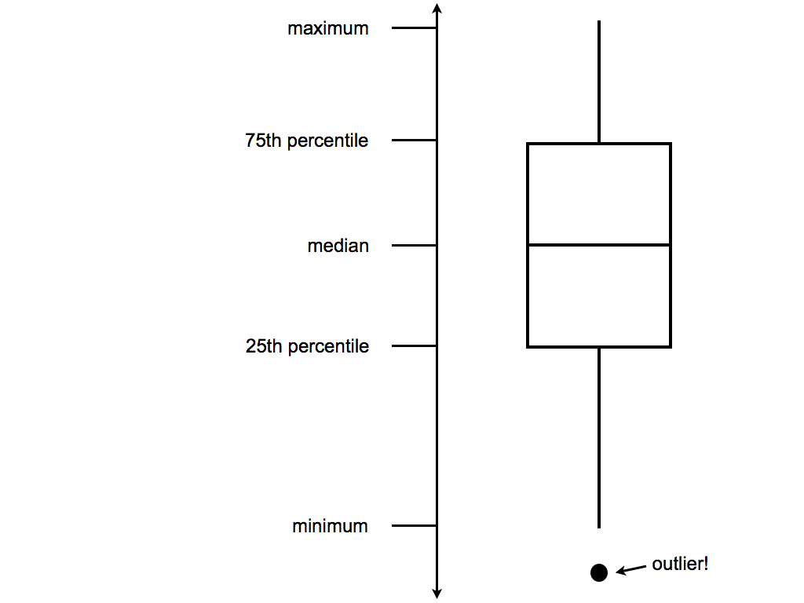

Here is an example:

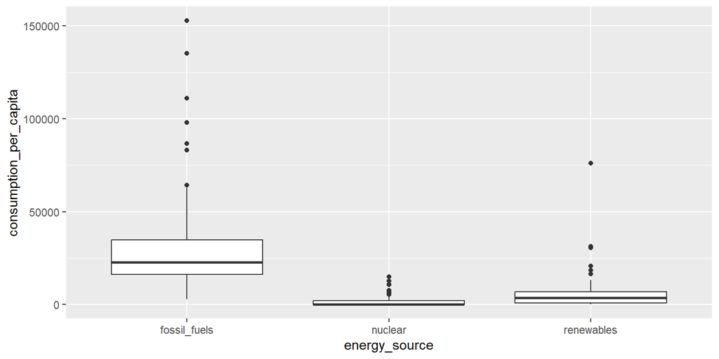

```r
ggplot(energy_per_capita_2021, aes(y=consumption_per_capita, x=energy_source)) +
    geom_boxplot()
```

Similarly, we can use *violin plots*, which are basically density plots on their sides:

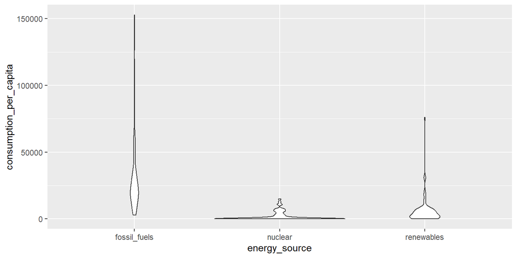

```r
ggplot(energy_per_capita_2021, aes(y=consumption_per_capita, x=energy_source)) +
    geom_violin()
```

We can make these violin plots slightly fancier and more informative by overlaying them with the individual data points and adding some color:

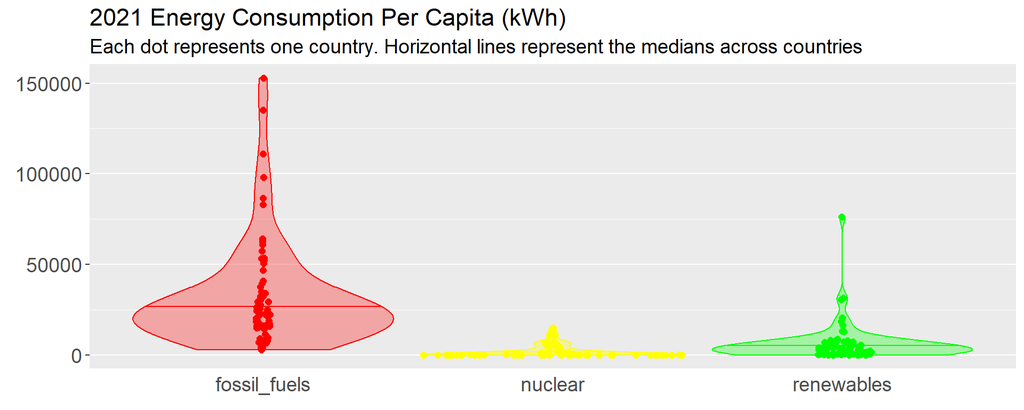

```r
library(ggforce)
ggplot(energy_per_capita_2021, aes(y=consumption_per_capita, x=energy_source,fill=energy_source,color=energy_source)) +
  scale_shape_identity() +
  theme(legend.position="none",text=element_text(size=14),
        axis.ticks.x=element_blank(),panel.grid.major.x = element_blank(), panel.grid.minor.x = element_blank(),
             axis.text = element_text(size = 14)) + labs(x=element_blank(),y=element_blank(),title="2021 Energy Consumption Per Capita (kWh)",subtitle="Each dot represents one country. Horizontal lines represent the medians across countries")+
  geom_sina(size = 2,
                alpha = 1,
                aes(shape = 16)) +
  geom_violin(position = position_nudge(x = 0, y = 0),
             adjust = 2,
             draw_quantiles = c(0.5),
             alpha = 0.3,
             trim = TRUE,
             scale = "width") +
  scale_fill_manual(values=c("red","yellow","green"))+
scale_color_manual(values=c("red","yellow","green"))+
  scale_x_discrete(labels = function(x) str_wrap(x, width = 10))
```

# 5 Visualizing Categorical vs Categorical Relationships

Let’s explore the following research question: “How has the number of countries who consume less than 80% of their energy from fossil fuels changed from 1991 to 2021?”

**Exercise 5.1 (Side-by-side bar plots)** We saw above that we can incorporate a new categorical variable into a visualization by using grouping features such as color or facets.

1. Construct the following 4 bar plot visualizations.

   ```r
   #a stacked bar plot
   ggplot(energy_per_capita1, aes(x=year, fill=less_than_eighty_percent_fossil_fuels))+
     geom_bar()+
     labs(y="Number of Countries",fill="Fossil Fuel Contribution Below 80%")

   #a side-by-side bar plot
   ggplot(energy_per_capita1, aes(x=year, fill=less_than_eighty_percent_fossil_fuels)) +
       geom_bar(position="dodge")+
       labs(y="Number of Countries",fill="Fossil Fuel Contribution Below 80%")

   #a proportional bar plot
   ggplot(energy_per_capita1, aes(x=year, fill=less_than_eighty_percent_fossil_fuels)) +
       geom_bar(position="fill")+
       labs(y="Portion of Reporting Countries",fill="Fossil Fuel Contribution Below 80%")

   #faceted bar plot
   ggplot(energy_per_capita1, aes(x=year, fill=less_than_eighty_percent_fossil_fuels)) +
       geom_bar() +
       facet_wrap( ~less_than_eighty_percent_fossil_fuels)+
       labs(y="Number of Countries",fill="Fossil Fuel Contribution Below 80%")
   ```

2. Name one pro and one con of using the “proportional bar plot” instead of one of the other three options.
3. What’s your favorite bar plot from part (a)? Why?

*Solution*.

2. Pro: it lets you focus on the blue, the countries that are below 80%. Con: it leaves out the fact that fewer countries are in the dataset in 1991
3. The side-by-side or the stacked, becuase I feel like they best show the change over time.

# 6 Practice

**Exercise 6.1 (Computation practice)**

1. In 2021, which country consumed the least energy from fossil fuels, per capita?
2. Which country in the data set reduced total fossil fuel energy consumption per capita by the greatest percentage from 2001 to 2021? How much did that country reduce it by?

```r
subset(energy_per_capita_2021, energy_source == "fossil_fuels") %>% arrange(consumption_per_capita, )
```

```
## # A tibble: 73 × 5
##    country     code  year  energy_source consumption_per_capita
##    <chr>       <chr> <fct> <chr>                          <dbl>
##  1 Bangladesh  BGD   2021  fossil_fuels                   2811.
##  2 Pakistan    PAK   2021  fossil_fuels                   4031.
##  3 Philippines PHL   2021  fossil_fuels                   4192.
##  4 India       IND   2021  fossil_fuels                   6074.
##  5 Peru        PER   2021  fossil_fuels                   6503.
##  6 Morocco     MAR   2021  fossil_fuels                   6690.
##  7 Indonesia   IDN   2021  fossil_fuels                   6995.
##  8 Colombia    COL   2021  fossil_fuels                   7691.
##  9 Ecuador     ECU   2021  fossil_fuels                   8065.
## 10 Brazil      BRA   2021  fossil_fuels                   9005.
## # ℹ 63 more rows
```

```r
diff_data <- energy_per_capita2
diff_data$percent_diff <- (energy_per_capita2$fossil_fuels_2001 - energy_per_capita2$fossil_fuels_2021)/energy_per_capita2$fossil_fuels_2001
diff_data %>% arrange(desc(percent_diff))
```

```
## # A tibble: 73 × 15
##    country        code  fossil_fuels_1991 fossil_fuels_2001 fossil_fuels_2011
##    <chr>          <chr>             <dbl>             <dbl>             <dbl>
##  1 Denmark        DNK              44483.            40975.            30781.
##  2 Venezuela      VEN              23530.            27035.            25450.
##  3 United Kingdom GBR              40890.            40767.            32301.
##  4 Ukraine        UKR              53157.            27115.            26472.
##  5 Finland        FIN              43961.            45737.            39870.
##  6 Sweden         SWE              27493.            26624.            22133.
##  7 Switzerland    CHE              26435.            26276.            21018.
##  8 Ireland        IRL              34312.            47042.            33906.
##  9 Luxembourg     LUX             102576.            89217.            91805.
## 10 France         FRA              30152.            29237.            23946.
## # ℹ 63 more rows
## # ℹ 10 more variables: fossil_fuels_2021 <dbl>, nuclear_1991 <dbl>,
## #   nuclear_2001 <dbl>, nuclear_2011 <dbl>, nuclear_2021 <dbl>,
## #   renewables_1991 <dbl>, renewables_2001 <dbl>, renewables_2011 <dbl>,
## #   renewables_2021 <dbl>, percent_diff <dbl>
```

*Solution*.

1. Bangladesh
2. Denmark, 53%

**Exercise 6.2 (Charting changes over time)** Finally, we are interested in two research questions: 1. Which countries are doing a good job of reducing their fossil fuel energy consumption? 2. To what extent are they doing this by increasing the portion of their energy consumption from nuclear and/or renewables?

1. Examine the two plots below. Does the first plot help you answer either or both of the research questions above? How about the second plot?
2. Recreate both plots as closely as possible. Hint: start by thinking about the glyphs, glyph-ready data, and which table you’ll want to use.

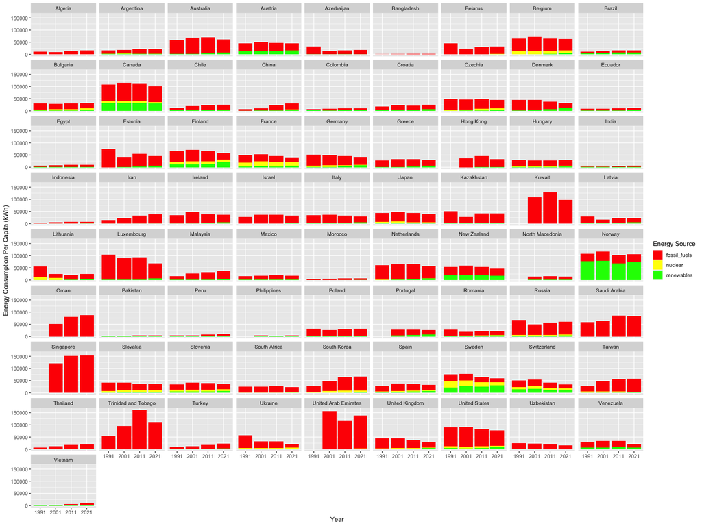

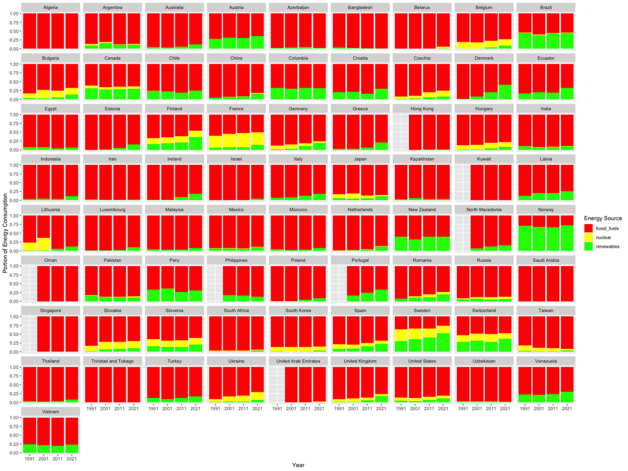

*Solution*.

1. The first plot helps you answer the first question, becuase you can see the total amount of energy consumption, the second plot helps you answer the second question because you can see the energy type breakdown.

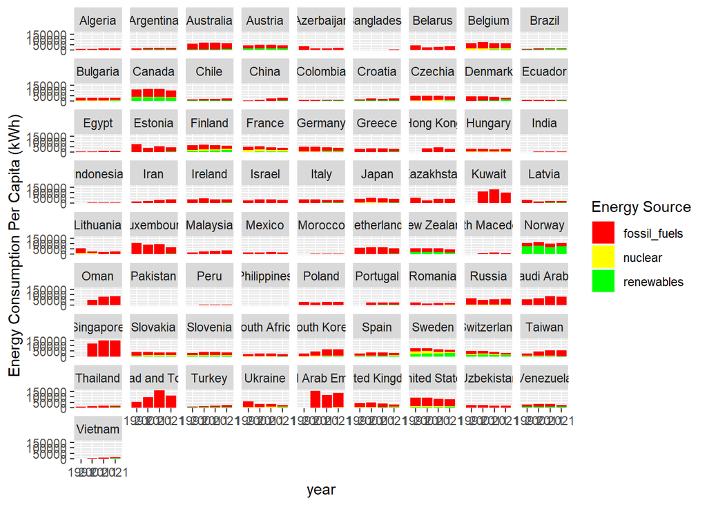

```r
ggplot(energy_per_capita3, aes(x=year, y=consumption_per_capita, fill=energy_source))+
  geom_bar(stat = "identity")+
  facet_wrap(~country)+
  scale_fill_manual(values=c("red","yellow","green"))+
  labs(y="Energy Consumption Per Capita (kWh)", fill="Energy Source")
```

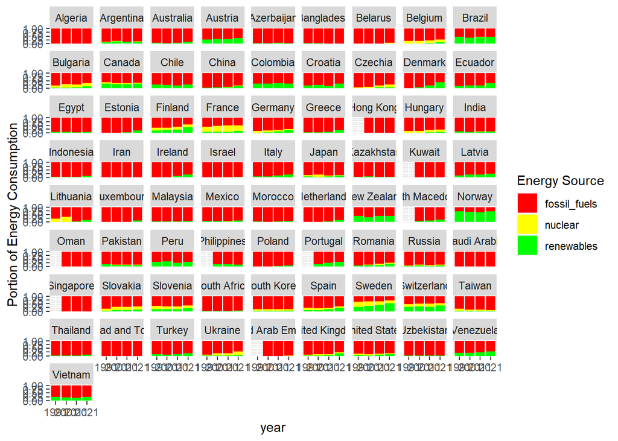

```r
ggplot(energy_per_capita3, aes(x=year, y=consumption_per_capita, fill=energy_source))+
  geom_bar(stat = "identity", position="fill")+
  facet_wrap(~country)+
  scale_fill_manual(values=c("red","yellow","green"))+
  labs(y="Portion of Energy Consumption", fill="Energy Source")
```